# Final_Project

Tessa Danehy, Josh Eiland, Chirag Kulkarni

11/17/2019

Since we are getting the data from the NFL Big Data Bowl competition, the database is pretty robust. After creating a missing values map (below), we can see that most of the information is complete, with the exception of weather data.

Temperature (and to a lesser extent humidity) information seems to be missing at various points throughout the data. This is curious as there is weather data out there and we could likely find a way to populate those fields knowing the day and location of the game. We may first see how significant temperature is in predicting rush yardage to determine if completing the temp data is worth it.

Following this, we looked at a summary of the data to determine 1) whether the data was in the right format and 2) if there were any unreasonable values. Again, the data from the NFL is pretty great so all the data came in the correct format (categoricals for team name, player name, location, etc). There are a few features that we may engineer though: age of player (from birth day) and minutes into game (from game clock).

For some next steps, we want to take a look at each of the column variables critically and determine which we want to test in a potential model. Ultimately, we will be experimenting with many different variables but we may rule some out from the offset. After that, we would like to connect to a database (NFL API) to get player stats and/or rankings. There is data out there such as Average Yards Per Play for each player and that could certainly improve our model.

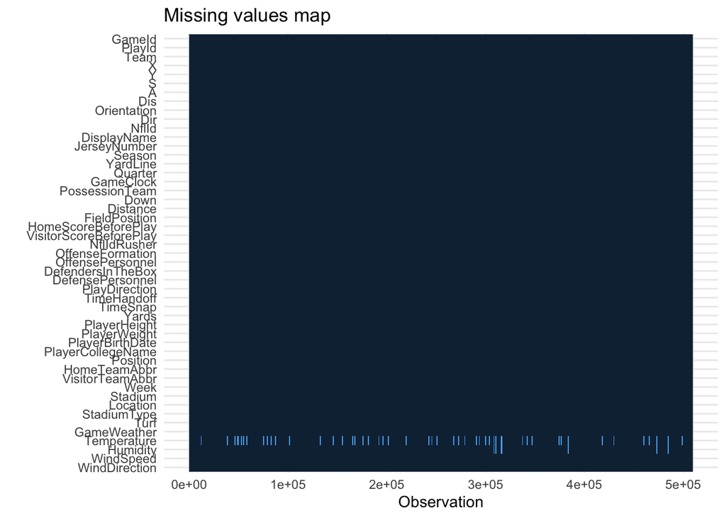

```r
missing_plot(data)
```

```r
summary(data)
```

```
##      GameId              PlayId            Team              X
##  Min.   :2.017e+09   Min.   :2.017e+13   away:254881   Min.   :  0.66
##  1st Qu.:2.017e+09   1st Qu.:2.017e+13   home:254881   1st Qu.: 39.09
##  Median :2.017e+09   Median :2.017e+13                 Median : 60.29
##  Mean   :2.018e+09   Mean   :2.018e+13                 Mean   : 60.04
##  3rd Qu.:2.018e+09   3rd Qu.:2.018e+13                 3rd Qu.: 80.97
##  Max.   :2.018e+09   Max.   :2.018e+13                 Max.   :116.84
##
##        Y               S               A               Dis
##  Min.   : 1.85   Min.   :0.000   Min.   : 0.000   Min.   :0.0000
##  1st Qu.:22.73   1st Qu.:1.500   1st Qu.: 0.940   1st Qu.:0.1700
##  Median :26.79   Median :2.470   Median : 1.540   Median :0.2700
##  Mean   :26.78   Mean   :2.592   Mean   : 1.683   Mean   :0.2794
##  3rd Qu.:30.86   3rd Qu.:3.560   3rd Qu.: 2.290   3rd Qu.:0.3900
##  Max.   :56.45   Max.   :9.410   Max.   :14.710   Max.   :1.3900
##
##   Orientation          Dir             NflId
##  Min.   :  0.00   Min.   :  0.00   Min.   :    222
##  1st Qu.: 90.63   1st Qu.: 89.83   1st Qu.:2532865
##  Median :179.70   Median :180.09   Median :2543765
##  Mean   :180.25   Mean   :179.93   Mean   :2344703
##  3rd Qu.:270.40   3rd Qu.:270.19   3rd Qu.:2555343
##  Max.   :360.00   Max.   :360.00   Max.   :2561671
##  NA's   :18       NA's   :14
##             DisplayName      JerseyNumber       Season        YardLine
##  Joe Thuney       :   847   Min.   : 1.00   Min.   :2017   Min.   : 1.00
##  Michael Thomas   :   847   1st Qu.:26.00   1st Qu.:2017   1st Qu.:20.00
##  Tom Brady        :   823   Median :56.00   Median :2017   Median :29.00
##  Rob Havenstein   :   797   Mean   :54.19   Mean   :2017   Mean   :28.37
##  Shaq Mason       :   796   3rd Qu.:78.00   3rd Qu.:2018   3rd Qu.:39.00
##  Ha Ha Clinton-Dix:   789   Max.   :99.00   Max.   :2018   Max.   :50.00
##  (Other)          :504863
##     Quarter         GameClock      PossessionTeam        Down
##  Min.   :1.000   15:00:00: 14476   NE     : 18700   Min.   :1.000
##  1st Qu.:1.000   02:00:00:  5236   LA     : 17952   1st Qu.:1.000
##  Median :3.000   14:54:00:  2156   BLT    : 17864   Median :1.000
##  Mean   :2.505   14:55:00:  1958   JAX    : 17490   Mean   :1.521
##  3rd Qu.:4.000   14:56:00:  1276   NO     : 17490   3rd Qu.:2.000
##  Max.   :5.000   14:20:00:  1188   SEA    : 17094   Max.   :4.000
##                  (Other) :483472   (Other):403172
```

[output cut: 73 more lines]

```
##  Grass                :166276   Cloudy       :114466   Min.   : 9.00
##  Natural Grass        :107096   Sunny        :105028   1st Qu.:48.00
##  Field Turf           : 47674   Partly Cloudy: 46068   Median :62.00
##  Artificial           : 44484   Clear        : 44264   Mean   :60.44
##  FieldTurf            : 33198                : 41690   3rd Qu.:73.00
##  UBU Speed Series-S5-M: 32890   Rain         : 18898   Max.   :97.00
##  (Other)              : 78144   (Other)      :139348   NA's   :48532
##     Humidity        WindSpeed      WindDirection
##  Min.   :  0.00          : 67430          : 79376
##  1st Qu.: 43.00   5      : 53284   NE     : 30250
##  Median : 59.00   6      : 41580   NW     : 27236
##  Mean   : 55.65   7      : 39578   SW     : 25828
##  3rd Qu.: 71.00   4      : 34584   SE     : 25784
##  Max.   :100.00   9      : 31328   WSW    : 24222
##  NA's   :6160     (Other):241978   (Other):297066
```